# Predictive Models

##### 4.2 building the model

```r
# build the model by manually selecting the parameters after the grid searches
hyperparams <- expand.grid(n.trees = 20,
                           interaction.depth = 4,
                           shrinkage = 0.01,
                           n.minobsinnode = 5)
fitControl <- trainControl(method = "repeatedcv",   # set up cross validation
                           ## 5-fold cross validation
                           number = 5,
                           ## repeat cross validation 5 times
                           repeats = 5,
                           ## Estimate class probabilities
                           classProbs = TRUE,
                           ## Evaluate performance using the following function which
                           ## computes sensitivity, specificity & area under the ROC
                           summaryFunction = twoClassSummary,
                           savePredictions = "all")
set.seed(696)
gbm_model8 <- train(credit ~.-id,
                    data = training,
                    method = "gbm",
                    tuneGrid = hyperparams,
                    metric = "ROC",
                    trControl = fitControl,
                    verbose = F)

gbm_model8
```

```
## Stochastic Gradient Boosting
##
## 318 samples
##  13 predictor
##   2 classes: 'Bad', 'Good'
##
## No pre-processing
## Resampling: Cross-Validated (5 fold, repeated 5 times)
## Summary of sample sizes: 255, 253, 255, 254, 255, 255, ...
## Resampling results:
##
##   ROC        Sens       Spec
##   0.7264364  0.2804558  1
##
## Tuning parameter 'n.trees' was held constant at a value of 20
##  4
## Tuning parameter 'shrinkage' was held constant at a value of
##  0.01
## Tuning parameter 'n.minobsinnode' was held constant at a value of 5
```

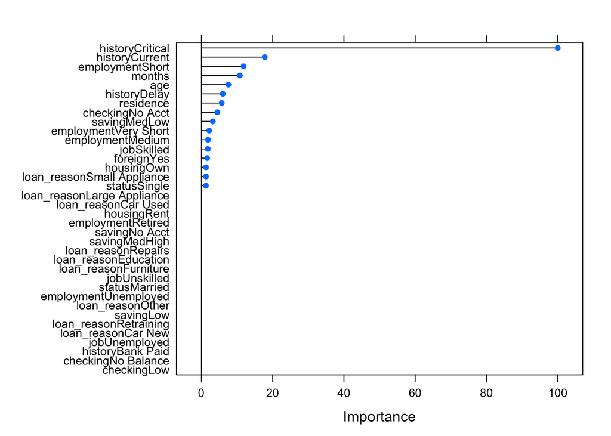

```r
gbm_var <- varImp(gbm_model8)
plot(gbm_var)
```

##### 4.3 using validation set to choose the best threshold

```r
# extracting class posterior probabilities
prob <- predict(gbm_model8, newdata = validation, type = 'prob')
# creating a vector of probability from tree prediction on the validation set
forest_val_prob <- prob[[2]]

# choosing the best therold for the classifer
library(ROCR)
threshold_pred <- prediction(forest_val_prob, validation$credit)
evaluation <- performance(threshold_pred, 'acc')
# Identify the best threshold
max <- which.max(evaluation@y.values[[1]])
val_accuracy <- evaluation@y.values[[1]][max]
gbm_threshold <- evaluation@x.values[[1]][max]
# reduce the threshold value a small degree so that the model could cover the true positives better
gbm_threshold <- gbm_threshold - 0.001
```

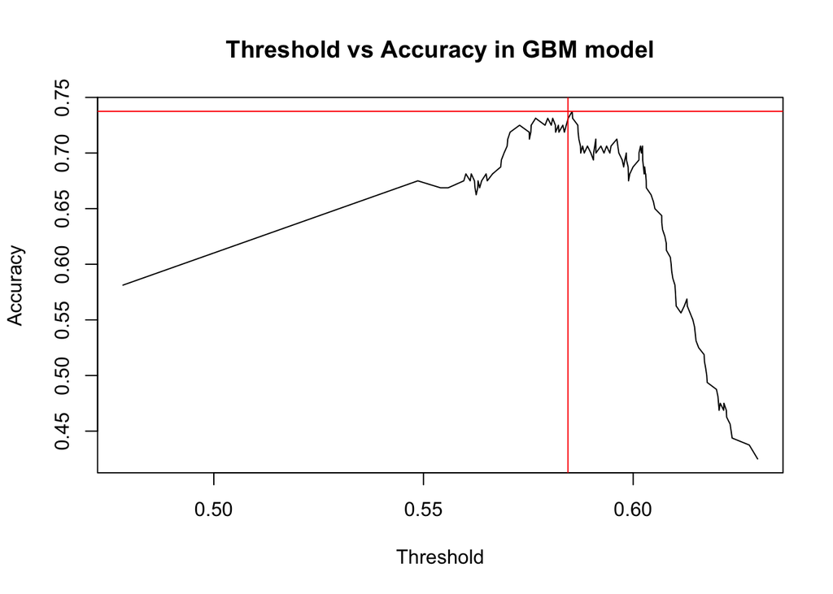

```r
plot(evaluation, main = 'Threshold vs Accuracy in GBM model', xlab = 'Threshold', ylab = 'Accuracy')
abline(h = val_accuracy, col = 'red')
abline(v = gbm_threshold, col = 'red')
```

```r
gbm_threshold
```

```
## [1] 0.5844529
```

##### 4.4 test the model on testing set

```r
# extracting class posterior probabilities
prob <- predict(gbm_model8, newdata = testing, type = 'prob')
# creating a vector of probability from tree prediction on the validation set
gbm_test_prob <- prob[[2]]
gbm_test_pred <- as.factor(ifelse(prob[[2]] >= gbm_threshold, "Good", "Bad"))
# accuracy level of the model on the testing set = 77%
confusionMatrix(testing$credit, gbm_test_pred, positive = 'Good')
```

```
## Confusion Matrix and Statistics
##
##           Reference
## Prediction Bad Good
##       Bad   42   24
##       Good  13   81
##
##                Accuracy : 0.7688
##                  95% CI : (0.6956, 0.8317)
##     No Information Rate : 0.6562
##     P-Value [Acc > NIR] : 0.001366
##
##                   Kappa : 0.5107
##
##  Mcnemar's Test P-Value : 0.100178
##
##             Sensitivity : 0.7714
##             Specificity : 0.7636
##          Pos Pred Value : 0.8617
##          Neg Pred Value : 0.6364
##              Prevalence : 0.6562
##          Detection Rate : 0.5062
##    Detection Prevalence : 0.5875
##       Balanced Accuracy : 0.7675
##
##        'Positive' Class : Good
##
```

```r
gbm_test_acc <- confusionMatrix(testing$credit, gbm_test_pred, positive = 'Good')[[3]][[1]]
gbm_test_sens <- confusionMatrix(testing$credit, gbm_test_pred, positive = 'Good')[[4]][[1]]
gbm_test_spec <- confusionMatrix(testing$credit, gbm_test_pred, positive = 'Good')[[4]][[2]]
```

##### 4.5 making predictions on df2, i.e. scoring sheet

```r
df2$gbm_prob <- predict(gbm_model8, newdata = df2, type = 'prob')[[2]]
df2$gbm_pred <- as.factor(ifelse(df2$gbm_prob >= gbm_threshold, "Good", "Bad"))
df2[,c('id','tree_pred', 'forest_pred', 'gbm_pred')]
```

```
##     id tree_pred forest_pred gbm_pred
## 1  781      Good        Good     Good
## 2  782      Good        Good     Good
## 3  783      Good        Good     Good
## 4  784      Good        Good     Good
## 5  785      Good        Good     Good
## 6  786      Good        Good     Good
## 7  787      Good        Good     Good
## 8  788      Good        Good     Good
## 9  789      Good        Good     Good
## 10 790      Good        Good     Good
## 11 791       Bad         Bad      Bad
## 12 792       Bad         Bad      Bad
## 13 793       Bad         Bad      Bad
```

### 5. Evaluating models’ performances

```r
# calculating the area under the ROC
prob_list <- list(tree_test_prob, forest_test_prob, gbm_test_prob)
auc <- c()
for(i in 1:3){
  t <- prediction(prob_list[[i]], testing$credit)
  v <- performance(t, "auc")
  auc <- c(auc, v@y.values[[1]])
}
# creating a vector of models' accuracy
acc <- c(tree_test_acc, forest_test_acc, gbm_test_acc)
# creating a vector of models' sensitivity
sens <- c(tree_test_sens, forest_test_sens, gbm_test_sens)
# creating a vector of models' specificity
spec <- c(tree_test_spec, forest_test_spec, gbm_test_spec)
# creating a matrix of metrics evaluating models' performaces
model_performance <- cbind(auc, acc, sens, spec)
rownames(model_performance) <- c('tree', 'forest', 'gbm')
model_performance
```

```
##              auc     acc      sens      spec
## tree   0.8210026 0.78750 0.7941176 0.7758621
## forest 0.7051096 0.63750 0.6636364 0.5800000
## gbm    0.8411509 0.76875 0.7714286 0.7636364
```

```r
df2[,c('id', 'tree_pred', 'forest_pred', 'gbm_pred')]
```

```
##     id tree_pred forest_pred gbm_pred
## 1  781      Good        Good     Good
## 2  782      Good        Good     Good
## 3  783      Good        Good     Good
## 4  784      Good        Good     Good
## 5  785      Good        Good     Good
## 6  786      Good        Good     Good
## 7  787      Good        Good     Good
## 8  788      Good        Good     Good
## 9  789      Good        Good     Good
## 10 790      Good        Good     Good
## 11 791       Bad         Bad      Bad
## 12 792       Bad         Bad      Bad
## 13 793       Bad         Bad      Bad
```

**CONCLUSION 9** Generally speaking, all three models have the same predictions in which id 782 & 783 have the good credit - the same results from dataframe df1. However, random forest seems to be the worst model which is not commonly worse than dececion tree. The reason for this could be that random forest select some “Features” randomly to build the Trees, if a “Feature” is important, sometimes Random Forest will build trees that will not have the significance that the“Feature” has in the final decision. In another word, it is the choice of mtry in this case. The best short-term model could be decision tree which is easily explainable to non-tech audience. However, gradient boosting has a slightly better area under the curve. It indicates the model’s power of distinguishing the binary outcomes efficiently. Moreover, to build a gradient boosting model, a grid search seems to be a must. If more time were invested for that process, better gradient boosting models could be used.  
Importantly, considering the sensitivity and specificity of the model is very crucial. It’s not just about to choose the model having the best accuracy. It’s about the business and their choice to have appropriate strategy associated with the decisions of whether or not a person is having a good credit. To think about this, further research is needed to consider the real business cost of the decision behind choosing appropriate threshold. Whether business owner needs to have more customers to give loans away or they have to be more selective/conservative on the criteria of choosing. Because sensitivity and specificity are all about that. Therefore, there is no absolute answer for choosing the right threshold. Contexts should be taken into consideration carefully.  
To explain the decision tree process to non-tech audience, it’s a series of question for their customers. It begins with customers’ history of their account. Then follow-up questions are used to determine whether those customers are qualified for the loan or not. This process is visualised easily by showing up the tree model to non-tech non-tech executives.

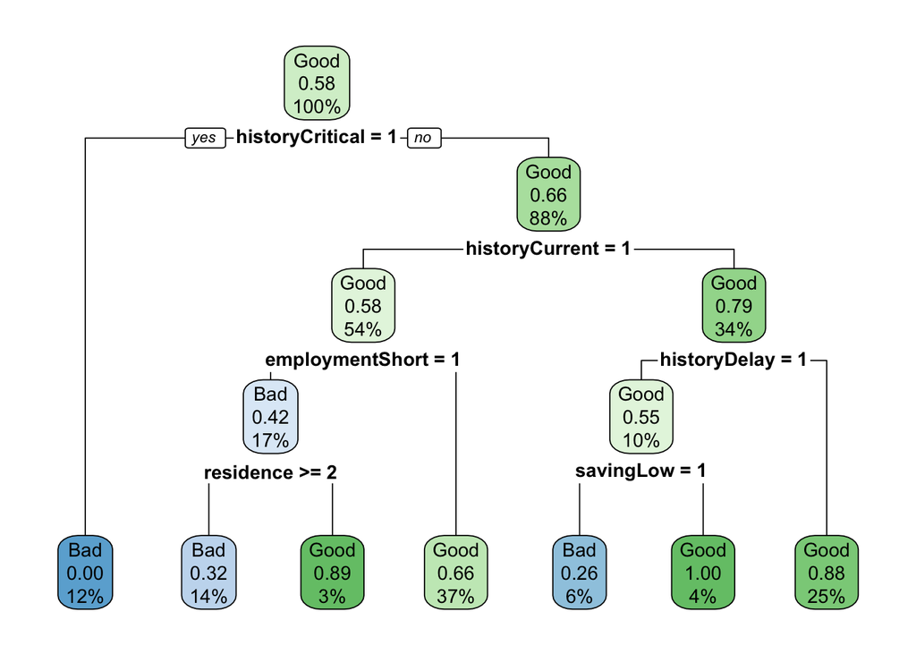

```r
rpart.plot::rpart.plot(tree_model2$finalModel)
```

### 6. Next Step

```r
# create a dataframe containing prediction probabilities
# given by tree, forest & gbm models on the test set
# the dataframe also includes numeric column of the credit (1 for Good & 0 for Bad)
numeric_credit_testing <- as.numeric(testing$credit) - 1
models_prob_predictions <- data.frame(tree_test_prob,
                                      forest_test_prob,
                                      gbm_test_prob,
                                      numeric_credit_testing)
head(models_prob_predictions)
```

```
##   tree_test_prob forest_test_prob gbm_test_prob numeric_credit_testing
## 1      0.6554622            0.660     0.5911804                      0
## 2      0.6554622            0.714     0.6012493                      0
## 3      0.6554622            0.656     0.5873926                      1
## 4      0.8846154            0.684     0.6170948                      1
## 5      0.3181818            0.506     0.5718736                      1
## 6      0.0000000            0.206     0.4783303                      0
```

```r
# # write a csv file so that the following question, i.e. h, can be refered to
# write.csv(models_prob_predictions, 'models_prob_predictions.csv', row.names = FALSE)
```

[^1]: Fawcett, T. (2006) An Introduction to ROC Analysis.Pattern Recognition Letters, 27, 861-874. https://doi.org/10.1016/j.patrec.2005.10.010